# Test

Stefanie Mayer

2022-11-09

```r
load("Tonga.RData")
```

## Introduction

When considering coral reef fish, influences on species distributions are ample. This ranges from biological factors such as competition, environmental factors such as temperature, or even historical factors such as disturbance events (Lecchini *et al*., 2003). Amid a worldwide biodiversity crisis, investigating complex interactions within marine ecosystems is crucial. One of the most common methods to understand community response to disturbances consists of computing beta diversity (Lamy*et al*, 2015). This can be done by assessing directional changes in species composition across a given environment. Particularly, the spatial beta diversity is studied to understand process that explain the spatial variation in community composition (Legendre & Gauthier, 2014).

Prior to 2016, the Kingdom of Tonga, a Polynesian country and archipelago, was data deficient. In 2016, a partnership was developed between the Tongan Ministry of Fisheries and James Cook University in Townsville, Australia with the aim of implementing a national coral monitoring project (Smallhorn-West*et al*, 2020). This allowed data Tonga’s first national coral reef monitoring expedition, in which 375 sites were surveyed across the three main island groups, Tongatapu, Ha’apai and Vava’u, to describe broad trends in the status of the country’s coral reefs and reef fish fishery. The primary aim of this research was to determine the present ecological status of Tonga’s reef ecosystem and determine the appropriate management strategies (Smallhorn-West*et al*, 2020). Moreover, socio-environmental variables were evaluated to highlight and mitigate potential threats to the islands. This uncovered an important degree of human pressure, particularly in the main island Tongatapu. This island presented high levels of over fishing, low coral cover, and high densities of *Diadema sp.* sea urchins. Likewise, additional studies have highlighted pronounced spatial heterogeneity due to the interacting effects of local environmental conditions (Adjeroud*et al*, 2012).

While it is clear that certain biological and environmental variables are affecting this community, further work is required to assess the generality of their influence on different fish species, at different scales, and also within the context of spatial structures. This report aims to highlight the drivers of beta diversity around Tongatapu. Specifically, to investigate the spatial structure of fish communities and to relate the spatial patterns to gradients in environmental variables.

## Materials

Coral reef ecological surveys conducted in the Kingdom of Tonga from 2016-2018 were obtained from PANGAEA®. [The dataset](https://doi.pangaea.de/10.1594/PANGAEA.917697) consisted of 375 sites surveyed across the Tongatapu, Ha’apai and Vava’u island groups. Data includes reef fish belt transects and benthic photo quadrats or point intercept data. In addition, the values of a range of socio-environmental predictor variables are also included in this data set. All surveys were conducted on SCUBA. Metadata on depth, location, transect length, width etc. are included in the data files as described in Smallhorn-West*et al*, 2020.

## Methods

### Exploratory Analysis

The primary purpose of this report was to determine the variables responsible for differences in beta diversity across sites in Tongatapu. For this reason, a broad approach was used to identify patterns in community, environmental, and spatial composition.

In attempts to reduce complexity and asymmetry of the data, a subset of 30 sites were analyzed with species having a minimum of 5 observations. However, throughout analyses, the complete data set explained more variation with complex analyses, particularly for Distance-Based Moran’s Eigenvector Maps. For consistency the complete data set was used for all analyses.

Analyses were primarily completed using density for the species assemblages due to differences in transect sizes. Specifically, some of the “large mobile fish species” such as the Yellowfin Parrotfish, had large variations in lengths ranging from 3cm to 27cm. Exploration was also completed using biomass for the species assemblages. This can be interesting as larger individuals often have larger impact on the organization, function, and dynamics of communities than smaller ones (Legendre *et al*, 1997). However, published length-weight relationships are not always reliable depending on the measurement type. For example, differences in fork length vs. total length which were not specified in the dataset.

Data was transformed prior to multivariate analysis with the exploration of Box-Cox family transformations. This was done to reduce the skewness of the data distribution and preserve Euclidean distance, using a coefficient having the property of double-zero asymmetrical. The LCD function (Legendre and Borcard, 2017) find the best exponent to reach multivariate normality. As the community data violated the assumptions of the functions (n<p) and were heavily asymmetrical, different exponents of the Box–Cox series were explored manually. This was done with the use of PCA to determine the coefficient preserving the Euclidean distance which explained most variation. These analyses suggested data was best transformed using with exponent 1 (no transformation) followed by chord transformations.

### Cluster Analysis

Cluster analyses were conducted to recognize discontinuous subsets in the environment, particularly spatial. Hierarchical clustering was chosen over non-hierarchical clustering as no specific number of clusters was expected. Using hierarchical clustering allowed non-overlapping clusters to be produced. Cophenetic correlations were calculated to assure the clustering model retained most of the information contained in the dissimilarity matrix. Gower distances were calculated to confirm the best clustering model of the dissimilarity matrix. To identify interpretable clusters, fusion levels values, average silhouette methods, binary matrices, and multiscale bootstrapping resampling methods were used. Spatial plots of the clustering methods were also created to represent results of our spatially explicit data.

```r
#Density per km
tonga.d<-cast(tonga, formula = site~species, sum, value = "density", fill = 0)
tonga.d<-column_to_rownames(tonga.d, var = "site")

#chord using library(vegan)
tonga.dc <- decostand(tonga.d, "nor")
tonga.dc.d <- dist(tonga.dc)
```

#### Clustering Method Selection

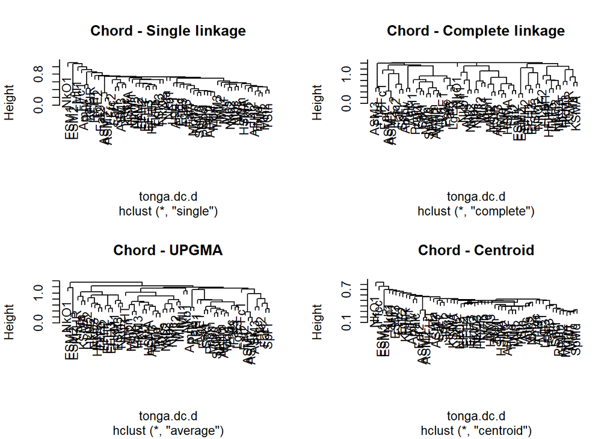

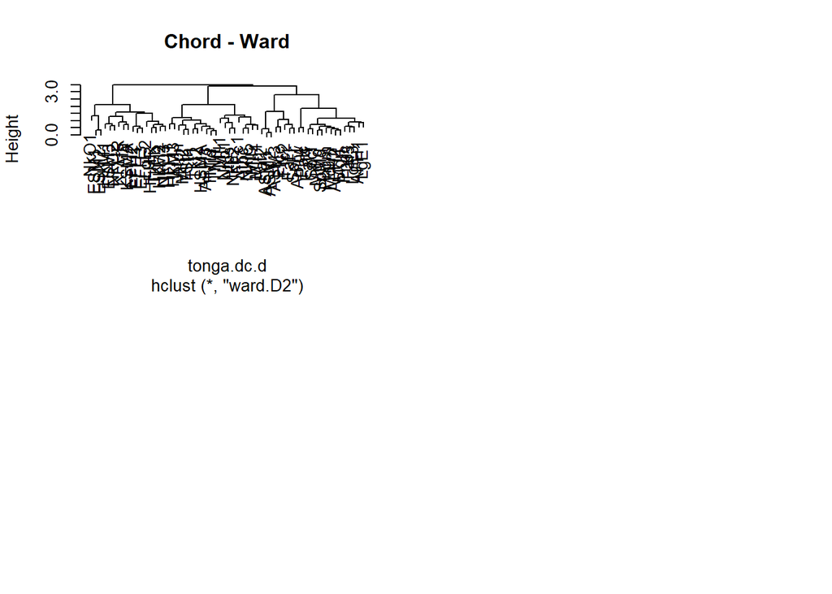

```
## [1] 0.6347326
## [1] 0.7449925
## [1] 0.8240864
## [1] 0.7234474
```

```r
# Gower (1983) distance
(gow.dist.single <- sum((tonga.dc.d - tonga.single.coph) ^ 2)) # 315.3156
## [1] 315.3156
(gow.dist.comp <- sum((tonga.dc.d - tonga.comp.coph) ^ 2)) #  104.5889
## [1] 104.5889
(gow.dist.UPGMA <- sum((tonga.dc.d - tonga.UPGMA.coph) ^ 2)) # 30.69564
## [1] 30.69564
(gow.dist.ward <- sum((tonga.dc.d - tonga.ward.coph) ^ 2)) # 6431.152
## [1] 6431.152
```

The cophenetic correlations, shepard-like diagrams, and Gower distances suggest that Unweighted pair-group method using arithmetic averages (UPGMA) clustering methods are best. However, given our data and the purpose of our analyses, Ward methods may be favorable. The analyses will continue comparing and contrasting the two.

#### Interpretable Clusters

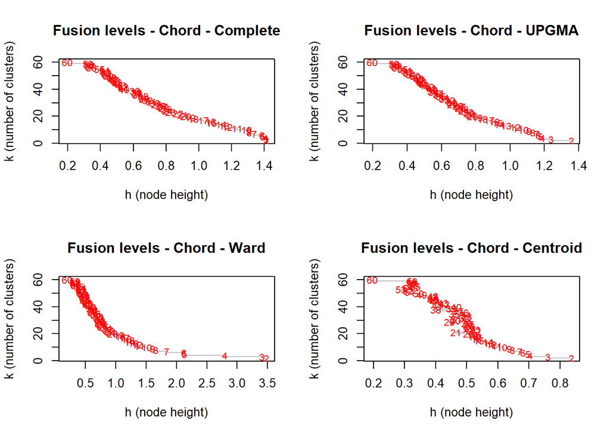

The graphs of the fusion level values seem to suggest 7 or 8 groups, and reaffirm are decision to continue to evaluate Ward clustering methods.

Next, we will compute and plot p-values for all clusters (edges) of the dendrogram via multiscale bootstrap resampling.

```
## Creating a temporary cluster...done:
## socket cluster with 7 nodes on host 'localhost'
## Multiscale bootstrap... Done.
## Creating a temporary cluster...done:
## socket cluster with 7 nodes on host 'localhost'
## Multiscale bootstrap... Done.
```

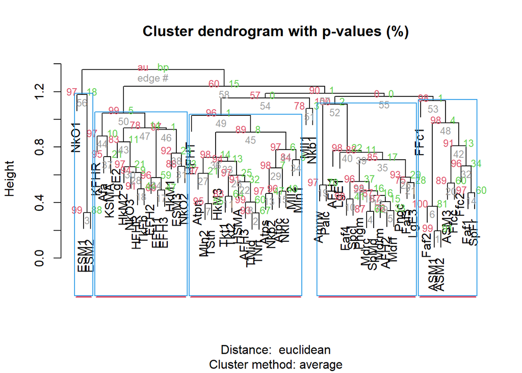

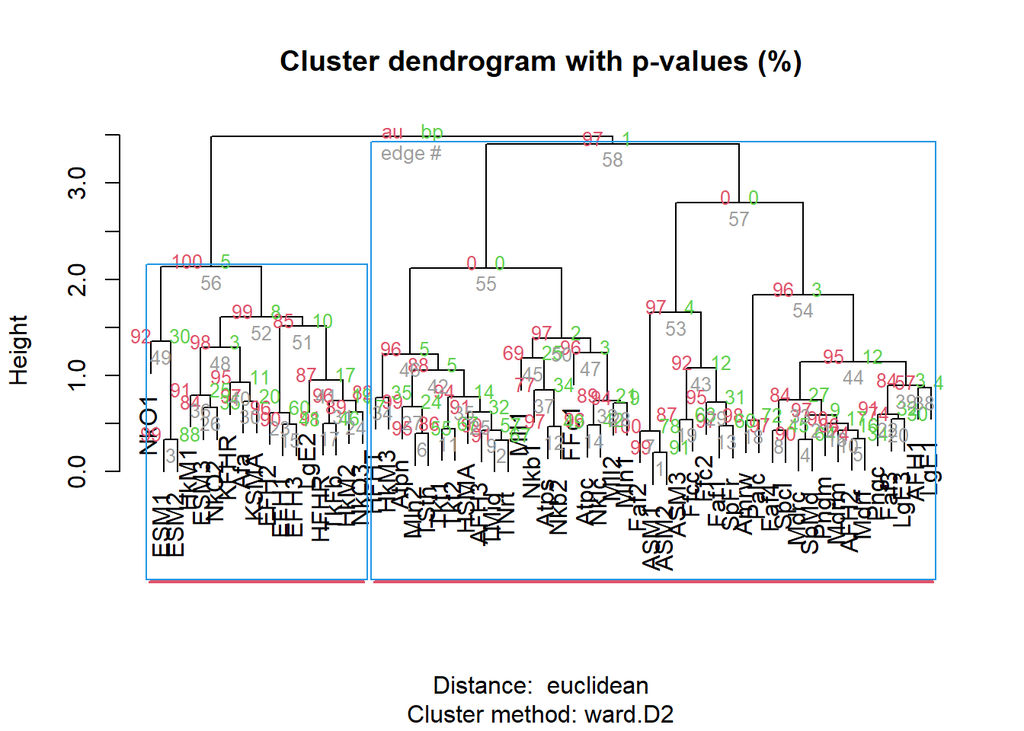

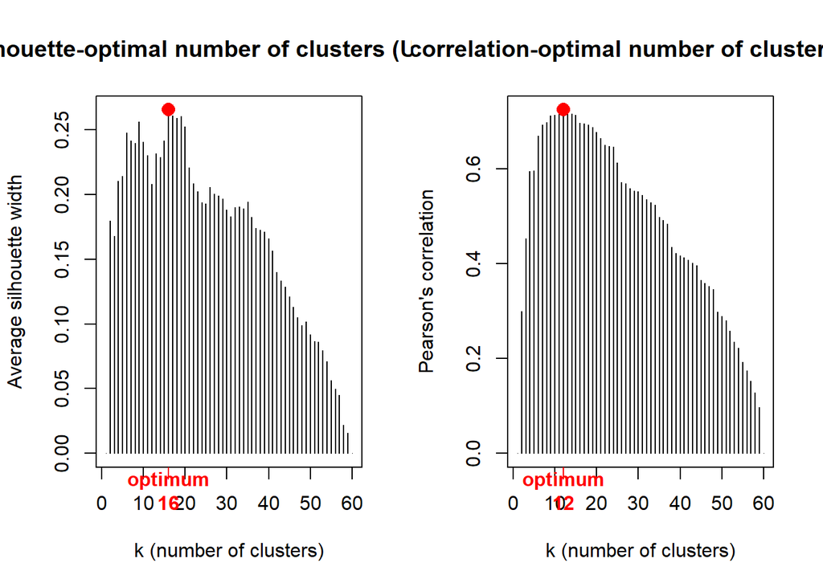

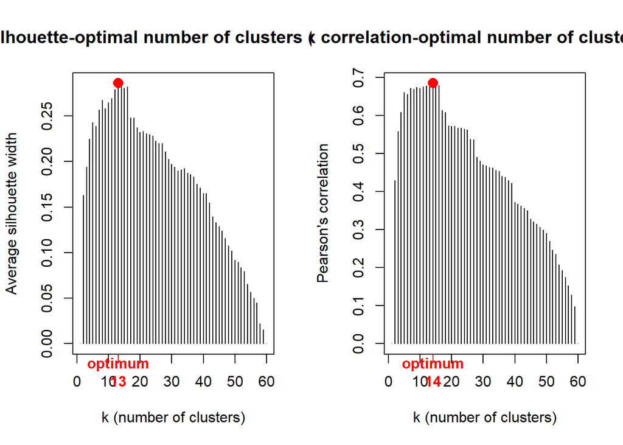

```r
#For for Ward's minimum variance clustering
par(mfrow = c(1, 2))
Si <- numeric(nrow(tonga.d))
for (k in 2:(nrow(tonga.d) - 1))
{
  sil <- silhouette(cutree(tonga.ward, k = k), tonga.dc.d)
  Si[k] <- summary(sil)$avg.width
}
k.best <- which.max(Si)
plot(
  1:nrow(tonga.d),
  Si,
  type = "h",
  main = "Silhouette-optimal number of clusters (Ward)",
  xlab = "k (number of clusters)",
  ylab = "Average silhouette width"
)
axis(
  1,
  k.best,
  paste("optimum", k.best, sep = "\n"),
  col = "red",
  font = 2,
  col.axis = "red"
)
points(k.best,
       max(Si),
       pch = 16,
       col = "red",
       cex = 1.5
)
kt <- data.frame(k = 1:nrow(tonga.d), r = 0)
for (i in 2:(nrow(tonga.d) - 1))
{
  gr <- cutree(tonga.ward, i)
  distgr <- grpdist(gr)
  mt <- cor(tonga.dc.d, distgr, method = "pearson")
  kt[i, 2] <- mt
}
k.best <- which.max(kt$r)
plot(
  kt$k,
  kt$r,
  type = "h",
  main = "Matrix correlation-optimal number of clusters (Ward)",
  xlab = "k (number of clusters)",
  ylab = "Pearson's correlation"
)
axis(
  1,
  k.best,
  paste("optimum", k.best, sep = "\n"),
  col = "red",
  font = 2,
  col.axis = "red"
)
points(k.best,
       max(kt$r),
       pch = 16,
       col = "red",
       cex = 1.5)
```

Barplot showing the average silhouette widths (Rousseeuw quality index) (left) for k = 2 to 60 groups and the matrix correlations between the original dissimilarity matrix and binary matrices computed from the dendrogram cut at various levels (right).These suggest the optimal number of clustering to be between 13 to 14 for Ward clustering methods, and 16 or 12 for the UPGMA clustering. Based on these combination of these test, we believe there will be 8 to 10 interpretable clusters.

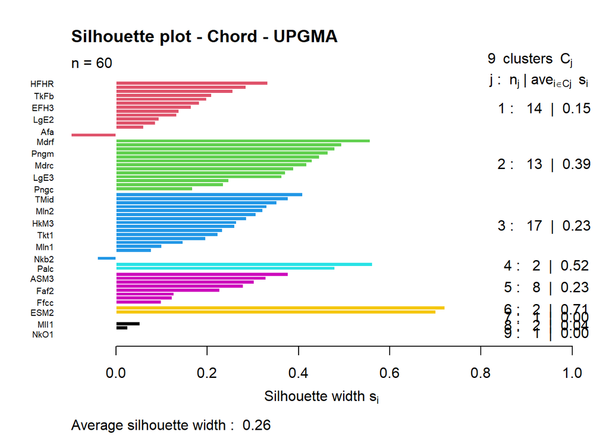

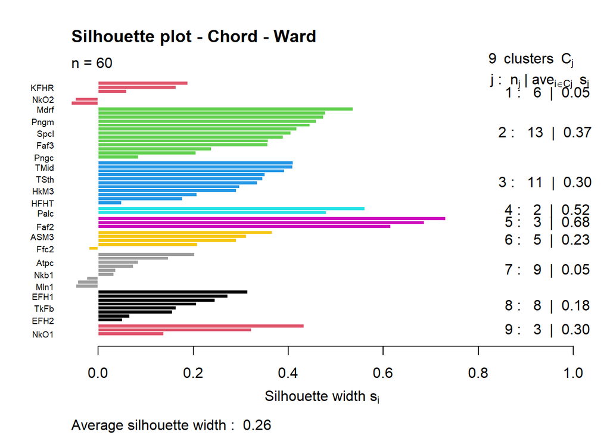

#### Cluster mapping

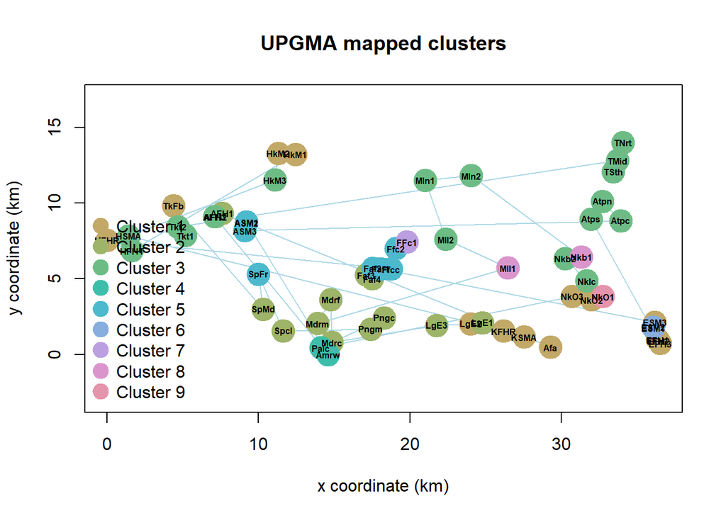

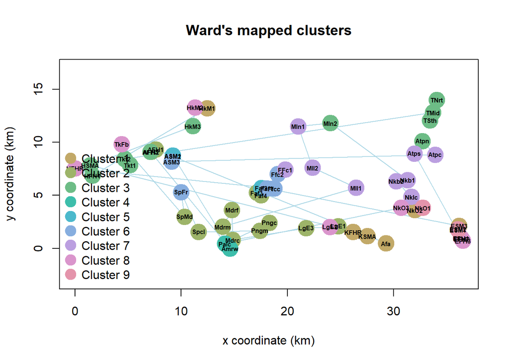

The selected cluster were plotted on the Tongutapu map to be used for comparison with spatial analyses, such as dbMEM and LCBD analysis. When comparing the results of the Ward and UPGMA clusters, slight variations are seen, with smaller groups seen with UPGMA compared to Ward.

### Unconstrained Ordination

#### Community

Chord transformed community data was explored using Principal Component Analysis. Species with high contribution to the explained variation were determined. Broken stick models were used to determine the number of interpretable components. Biplots were created using the cleanplot() function. Scaling 1 was used to visualize the association among objects, with variables whose vectors exited the circle of equilibrium contributing more to the explained variation of the PC axes. The goodness function was used to identify that reached a cumulative R2 score of at least 0.4 on the represented axes. To explain or confirm differences between groups of sites, additional PCA biplots were constructed using previous Ward and UPGMA clustering. Here clusters of sites were identified by colour.

```r
#Preparing the community matrices of abundance, density, and biomass for multivariate analysis using chord transformations
tonga.a<-cast(tonga, formula = site~species, sum, value = "abundance", fill = 0) #raw abundance
tonga.a<-column_to_rownames(tonga.a, var ="site")
tonga.ac <- decostand(tonga.a, "nor")
tonga.ac.d <- dist(tonga.ac)
tonga.ac.pca <- rda(tonga.ac)

tonga.d<-cast(tonga, formula = site~species, sum, value = "density", fill = 0) #Density per km
tonga.d<-column_to_rownames(tonga.d, var = "site")
tonga.dc <- decostand(tonga.d, "nor")
tonga.dc.d <- dist(tonga.dc)
tonga.dc.pca <- rda(tonga.dc)

tonga.bkm<-cast(tonga, formula = site~species, sum, value  = "biomass_1000mkg", fill = 0) #biomass
tonga.bkm<-column_to_rownames(tonga.bkm, var ="site")
tonga.bkmc <- decostand(tonga.bkm, "nor")
tonga.bkmc.d <- dist(tonga.bkmc)
tonga.bkmc.pca <- rda(tonga.bkmc)
```

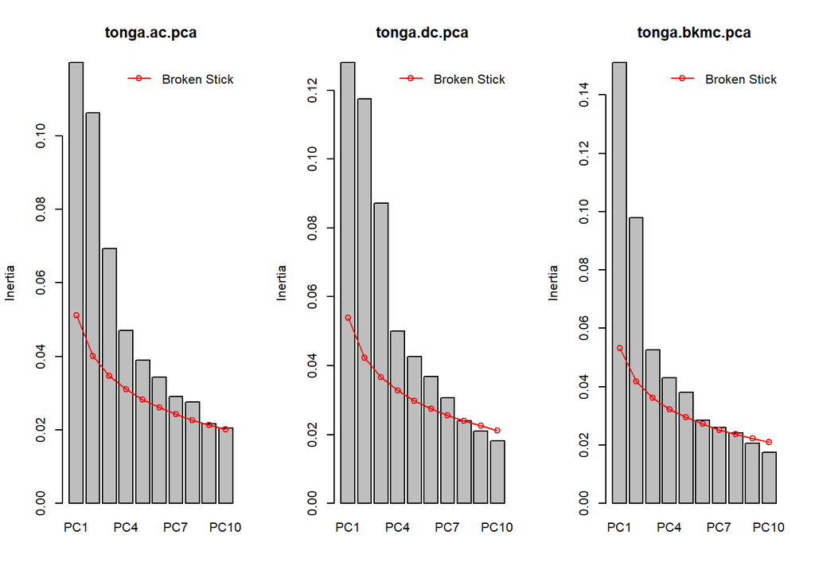

```r
#Comparing pca summaries for abundance, density, biomass
summary(tonga.ac.pca)
summary(tonga.dc.pca)
summary(tonga.bkmc.pca)
```

The PCA summaries suggest density explains slightly more variation (68.24%) than abundance (64.67%) or biomass (67.41%) when using the chord transformations. The broken stick models coupled with the summaries suggest that at least 3 of the PC axes should be visualized. For example, for density, the amount of variation explained by the 3rd axes (12.71%) is almost equally important as the first two axes (18.75% on PC1 and 17.21% for PC2). With the 4th PC explaining 7.3% of the variation, almost half of PC3, we are content with the first 3 axes. However, given the broken stick model, it could be interesting to run the PC axes through an NMDS. Given that density explains more variation on the first 3 axes (48.73% compared to 44.72% for biomass), we are more interested this measure for the PCA biplots, but both are compared.

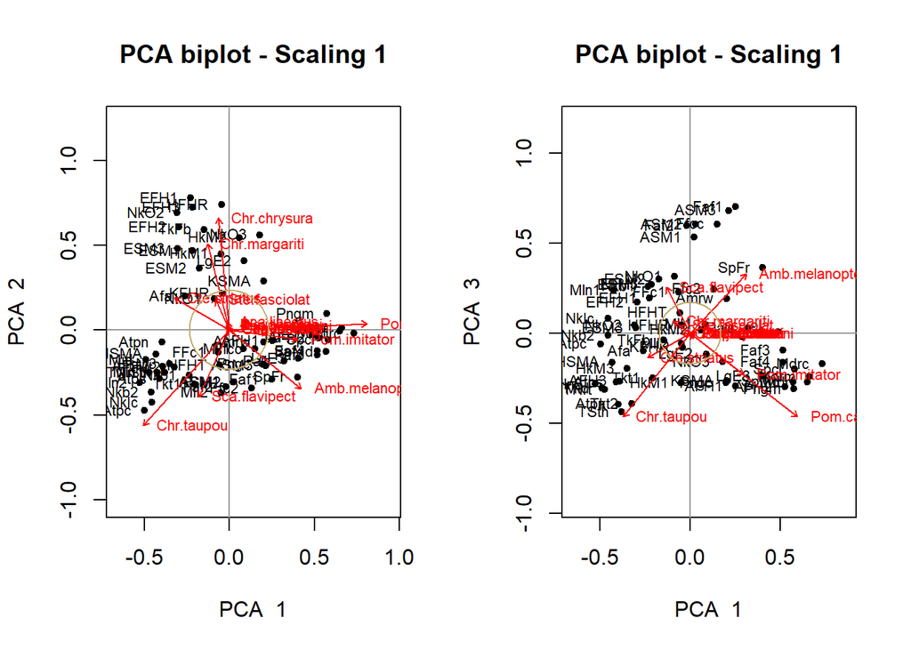

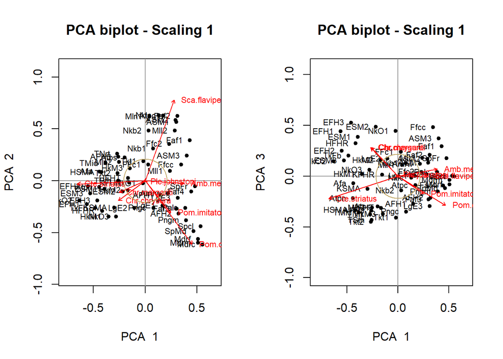

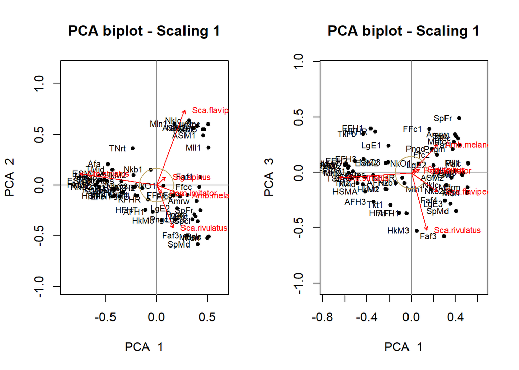

The PCA biplots show that the following species explaining most of the variance in terms of density to be:

- PC1: *Pomacentrus callainus , Pomacentrus imitator and Chrysiptera taupou*
- PC2: *Chromis margaritifer and Chromis chrysura*
- PC3: *Amblyglyphidodon melanopterus*

However, when we look at biplots using biomass, we observe different species: *Scarus rivulatus, Scarus flavipectoralis,* and *Ctenochaetus striatus.* These species do not appear on the density biplots unless the cumulative R2 scores is set to 0.3.

When comparing density to abundance, we see differences due to sampling. This is clear when taking *Scarus flavipectoralis,* the yellow parrot fish, as an example. This fish is considered a *large mobile* species and was counted within a 5m belt. However, it’s recorded range size varies between 3cm to 27 cm, likely including juveniles. In addition, these juveniles have different behaviours and patterns and are often counted with high abundances (Overholtzer & Motta, 1999). The biplots help visualize this bias and suggest that the analyses should using density .

Overall, the amount of information lost when comparing PC1~PC2, to PC1~PC3 does not seem to be crucial.

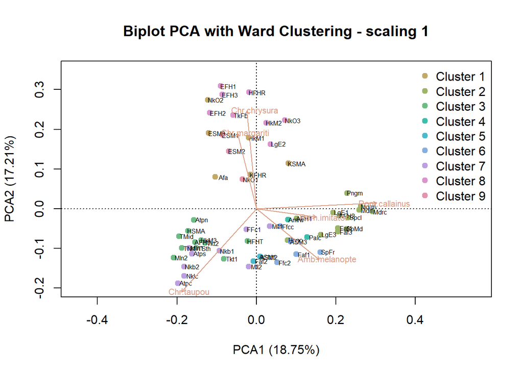

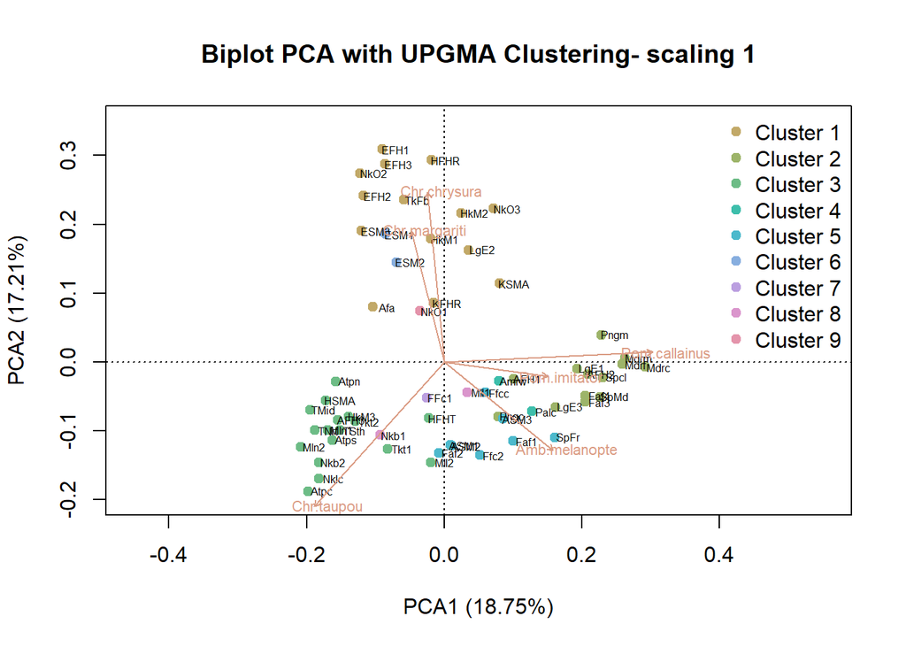

The biplots highlight species which may be influencing the clusters. In addition we see clear groupings along the 2nd axis.

#### Environment

Three primary environmental groups of environmental variables were used for the analyses; general environmental variables, distances, and benthic cover (Table 1.). These environmental variables were analyzed as separate matrices, as combined matrices, and through variation partitioning. Ordination methods (PCA) were used to visualize the variability of the sites in terms of environmental variables. For this, environmental variables were standardized using the scale argument to become dimensionally heterogeneous. Multicollinearity was measured using variance inflation factor (VIF), with variables with VIF > 5 removed.

| Environmental Variables | General_e1 | Distances_e5 | Benthic Cover_e7 | e1.5 | e1.5.7 |
| --- | --- | --- | --- | --- | --- |
| Visibility | O |  |  | O | O |
| Depth | O |  |  | O | O |
| Wave Energy | O |  |  | O | O |
| Fishing Pressure | O |  |  | O | O |
| Slope | O |  |  | O | O |
| Rugosity | O |  |  | O | O |
| Distance to land |  | O |  | O | O |
| Distance to 10m |  | O |  | O | O |
| Distance to 20m |  | O |  | O | O |
| Distance to market |  | O |  | O | O |
| Distance to lagoon |  | O |  | O | O |
| Distance to village |  | O |  | O | O |
| Hard Corals |  |  | O |  | O |
| Fire Corals |  |  | O |  | O |
| Invertebrates |  |  | O |  | O |
| Soft Corals |  |  | O |  | O |
| Sponges |  |  | O |  | O |
|  |  |  | O |  | O |

For the full methods on environmental variables, see “Exploratory.R”. In addition, see markdown file on R. to see exploratory analyses hidden with include=FALSE.

```r
#Multicolinearity Analysis using Kobe's VIF function
VIF_analysis(e1) #none over 5
VIF_analysis(e5) #none over 5
VIF_analysis(e7)
VIF_analysis(e7[,-1])#none over 5
e7<-e7[,-1] #new env matrix
VIF_analysis(e7)
VIF_analysis(e1.5) #market VIF > 5
VIF_analysis(e1.5[-11])
e1.5<-e1.5[,-11] #new env matrix
VIF_analysis(e1.5.7) #market VIF > 5
VIF_analysis(e1.5.7[,-14, -3])
VIF_analysis(dplyr::select(e1.5.7, -3, -14)) #remove algae and sst
e1.5.7<-dplyr::select(e1.5.7, -3, -14) #new env matrix
VIF_analysis(e1.5.7)
```

Following the VIF analyses, algae was removed from e7, market removed from e1.5 and algae and sst from e1.5.7 to reduce multicollinearity.

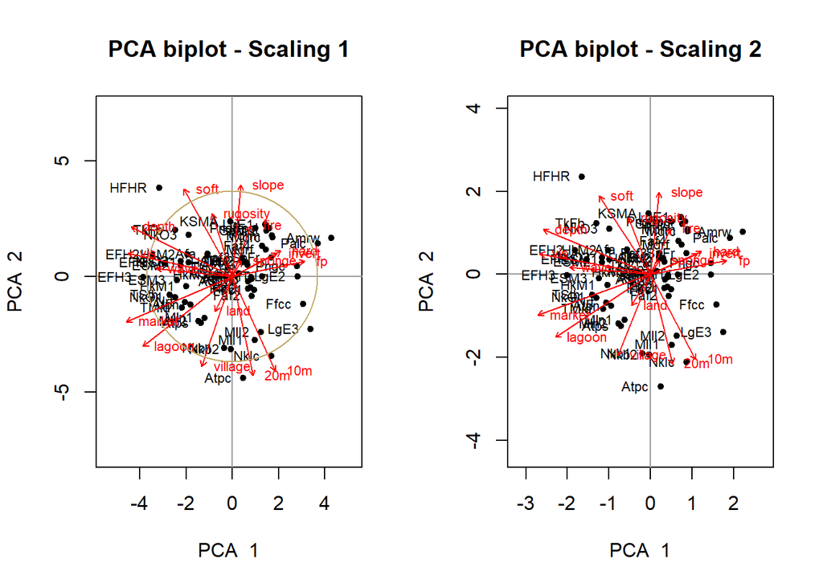

### Constrained Ordination

Indirect gradient analyses were completed to explore the relationship between the community data and the environmental variables. Canonical redundancy analyses (RDA) were used to examine the effects of the environmental variables on the community. The ordiR2step() function from the vegan package was used to select environmental variables which significantly increases the model’s adjusted R2. The significance of each model and their canonical axes were tested using permutation test. A final environmental matrix was created using variables from the model with the highest Adjusted R2 and lowest AIC. Results of the ordination were displayed using the triplots() function. Additional triplots were constructed using previous Ward and UPGMA clustering with clusters of sites identified by colour.

```r
#general env
mod.pc1.e1 <- lm(site.scores$PC1~., e1)
summary(mod.pc1.e1) #sst, rugosity
mod.pc2.e1 <- lm(site.scores$PC2~., e1)
summary(mod.pc2.e1) #sst

#distances
mod.pc1.e5 <- lm(site.scores$PC1~., e5)
summary(mod.pc1.e5) #20m, market, village
mod.pc2.e5 <- lm(site.scores$PC2~., e5)
summary(mod.pc2.e5) #20m, lagoon, village

#benthic cover
mod.pc1.e7 <- lm(site.scores$PC1~., e7)
summary(mod.pc1.e7) #invert
mod.pc2.e7 <- lm(site.scores$PC2~., e7)
summary(mod.pc2.e7) #none?


#Stepwise selection
#PC1
zero.pc1.e1<- lm(site.scores$PC1~1, e1)
mod.pc1.e1.red <- step(zero.pc1.e1, formula(mod.pc1.e1), direction="both")
summary(mod.pc1.e1.red)
mod.pc1.e1.red$anova # AIC=-250.15 : PC1 ~ sst +  rugosity
#PC2
zero.pc2.e1 <- lm(site.scores$PC2~1, e1)
mod.pc2.e1.red <- step(zero.pc2.e1, formula(mod.pc2.e1), direction="both")
summary(mod.pc2.e1.red)
# AIC=-254.87 : PC2 ~depth

#PC1
zero.pc1.e5<- lm(site.scores$PC1~1, e5)
mod.pc1.e5.red <- step(zero.pc1.e5, formula(mod.pc1.e5), direction="both")
summary(mod.pc1.e5.red) #AIC=-261.39: PC1 ~ market + `20m` + village
#PC2
zero.pc2.e5 <- lm(site.scores$PC2~1, e5)
mod.pc2.e5.red <- step(zero.pc2.e5, formula(mod.pc2.e5), direction="both")
summary(mod.pc2.e5.red) #AIC=-273.89: PC1 ~ `20m` + market + village + lagoon

#PC1
zero.pc1.e7<- lm(site.scores$PC1~1, e7)
mod.pc1.e7.red <- step(zero.pc1.e7, formula(mod.pc1.e7), direction="both")
summary(mod.pc1.e7.red) #AIC=-235.76 - PC1 ~ invert
#PC2
zero.pc2.e7 <- lm(site.scores$PC2~1, e7)
mod.pc2.e7.red <- step(zero.pc2.e7, formula(mod.pc2.e7), direction="both")
summary(mod.pc2.e7.red) #AIC=-239.89 - site.scores$PC2 ~ hard + soft
```

```r
rda.e1 <- rda(tonga.dc, e1)
anova(rda.e1) # e1 explains a significant proportion of the variance of Y.
rda.e5 <- rda(tonga.dc, e5)
anova(rda.e5) # e5 explains a significant proportion of the variance of Y.
rda.e7 <- rda(tonga.dc, e7)
anova(rda.e7) # e7 explains a significant proportion of the variance of Y.
rda.e1.5 <- rda(tonga.dc, e1.5)
anova(rda.e1.5) # e1.5.7 explains a significant proportion of the variance of Y.
rda.e1.5.7 <- rda(tonga.dc, e1.5.7)
anova(rda.e1.5.7) # e1.5.7 explains a significant proportion of the variance of Y.
```

```r
mod0.e1<-rda(tonga.dc~1, e1)
mod1.e1<-rda(tonga.dc~., e1)
step.e1<-ordiR2step(mod0.e1, mod1.e1)
e1.anova<-step.e1$anova

mod0.e5<-rda(tonga.dc~1, e5)
mod1.e5<-rda(tonga.dc~., e5)
step.e5<-ordiR2step(mod0.e5, mod1.e5)
e5.anova<-step.e5$anova

mod0.e7<-rda(tonga.dc~1, e7)
mod1.e7<-rda(tonga.dc~., e7)
step.e7<-ordiR2step(mod0.e7, mod1.e7)
e7.anova<-step.e7$anova

mod0.e1.5<-rda(tonga.dc~1, e1.5)
mod1.e1.5<-rda(tonga.dc~., e1.5)
step.e1.5<-ordiR2step(mod0.e1.5, mod1.e1.5)
e15.anova<-step.e1.5$anova

mod0.e1.5.7<-rda(tonga.dc~1, e1.5.7)
mod1.e1.5.7<-rda(tonga.dc~., e1.5.7)
step.e1.5.7<-ordiR2step(mod0.e1.5.7, mod1.e1.5.7)
e157.anova<-step.e1.5.7$anova
```

```r
RsquareAdj(rda.e1.5.7)$adj.r.squared
## [1] 0.4091631
RsquareAdj(step.e1.5.7)$adj.r.squared
## [1] 0.3908369
```

[output not shown]

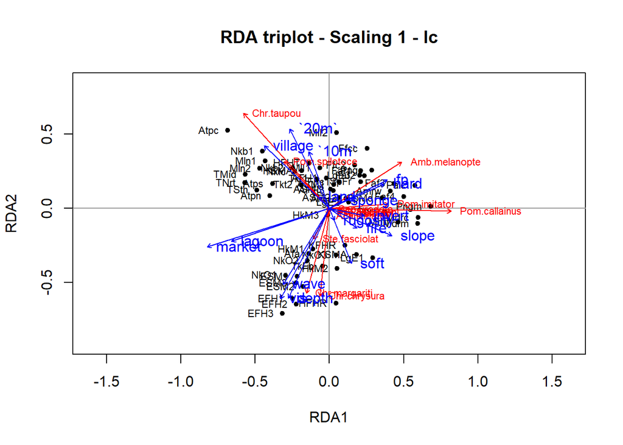

[output not shown]

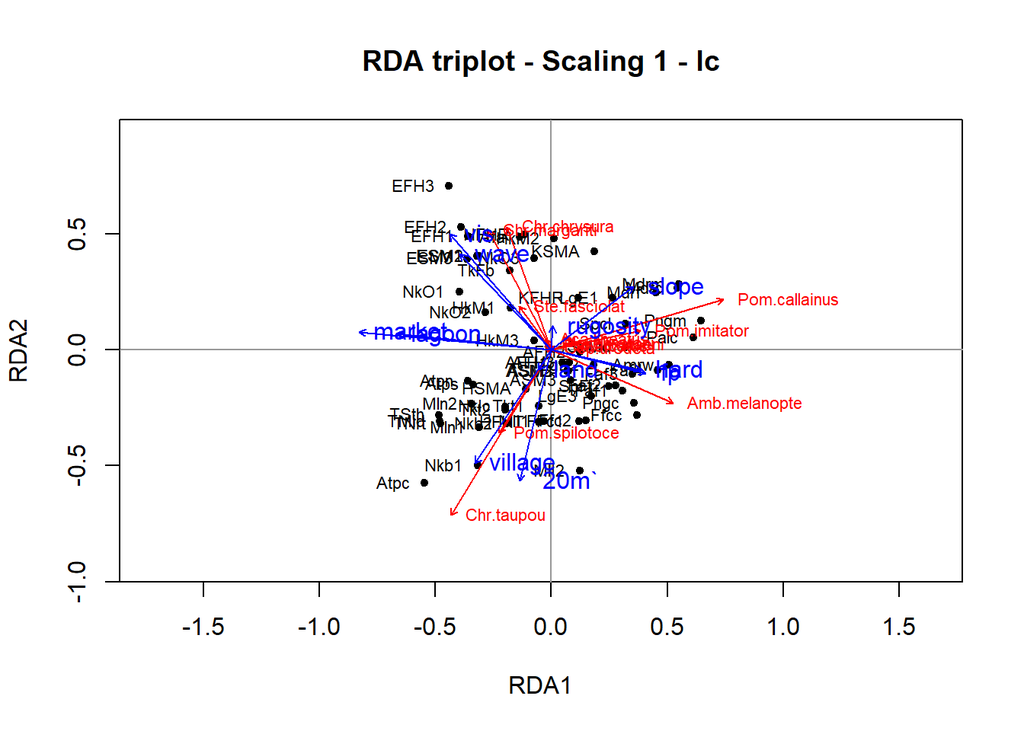

The ordiR2step() function selects the best model for the given environmental matrices, by comparing the full and reduced model. The criteria for including the variable is based on both significance of the newly selected variables, and the comparison of adjusted variation j) explained by the selected variables to R^2_adj explained by the global model (with all variables); if the new variable is not significant or the R^2_adj of the model including this new variable would exceed the R^2_adj of the global model, the selection will be stopped. Comparing the models suggest that using the environmental matrix with more variables (e1.5.7) explains most variation. In addition, analyses did not seem to suggest variance partitioning between different environmental matrices to increase the amount of variation explained in the community.

When comparing the final ordistep model to the full model:

rda(formula = tonga.dc ~ market + `20m` + vis + village + rugosity + hard + lagoon + land + wave + fp + slope, data = e1.5.7) rda(formula = tonga.dc ~ vis + depth + wave + fp + slope + rugosity + land + `10m` + `20m` + market + lagoon + village + hard + fire + invert + soft + sponge, data = e1.5.7)

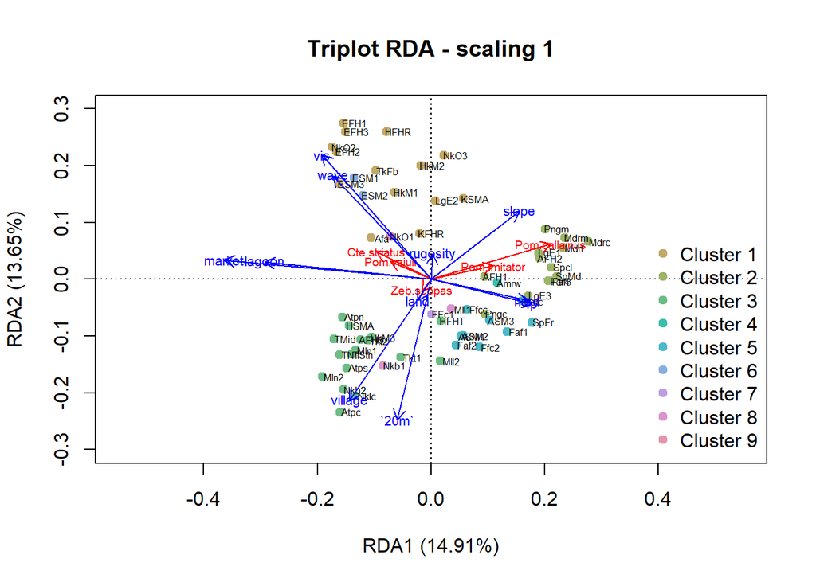

### Spatial

Geographic position data (latitude and longitude) of each site were transformed to Cartesian coordinates using the “geoXY” function in the SoDA package to identify linear trends in community composition. Once identified, the linear spatial trends present in the response data were removed prior to spatial analysis with distance-based Moran’s Eigenvector Maps. Variance partitioning was used to quantify the relative effects of environmental and spatial variables in shaping the reef fish communities. Finally, as a complement to the spatial eigenfunction analyses, local contribution to beta diversity (LCBD) scores were generated for each sample and used to identify those samples where the assemblage composition differed significantly from that of the mean assemblage. LCBD scores were generated from the chord distance matrix using the “LCBD.comp” function in the adespatial package. Resulting p-values were adjusted using the Holm correction for multiple comparisons.

[figure not shown]

```r
tonga.xy.c<-scale(tonga.xy, center = TRUE, scale = FALSE)
tonga.dc.det <- resid(lm(as.matrix(tonga.dc) ~ ., data = tonga.xy)) #detrend
tonga.dc.D1 <- dist(tonga.dc.det) #turn detrend into distance
## Spatial data: linear trends
rda.xy <- rda(tonga.dc, tonga.xy)
RsquareAdj(rda.xy)
anova(rda.xy)
# 0.12 explained with linear coordinates, so the residuals contain...
var.res=1-0.1198403 #= 0.8801597
var.res #so, this is what's left to explain with (not linear coordinates)
```

[figure not shown]

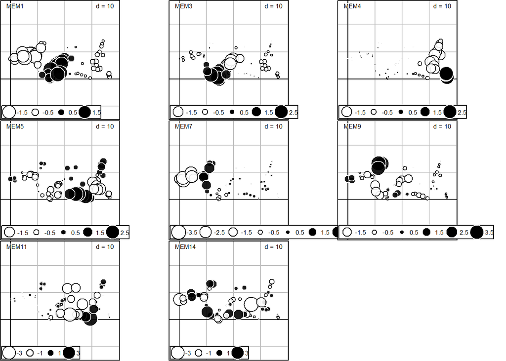

```r
s.value(tonga.xy, dbmem.red, method = "size",symbol = "circle")
```

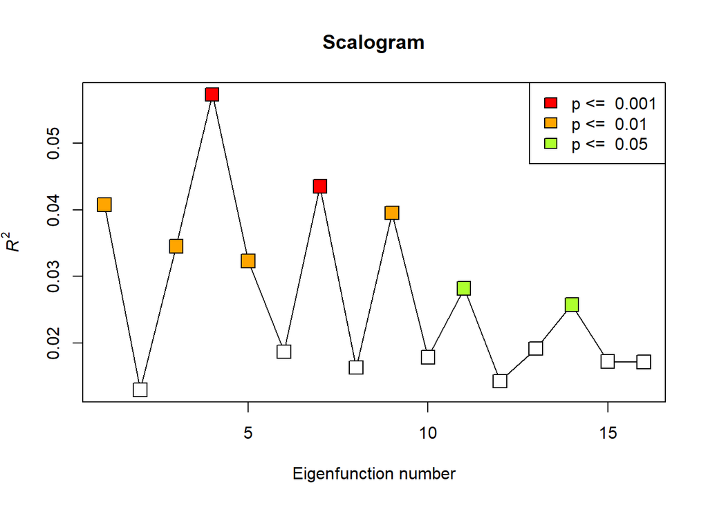

```r
source("final/functions/scalog.R")
scalog(tonga.dbmem.rda)
```

The eigenvector-based spatial analyses is applied to the detrended data, with 16 dbMEM eigenvectors with positive spatial correlation identified. Using forward selection, 8 of the dbMEMs are selected and show significant spatial patterns with a significant model and adjusted R2 of 0.1925. The scalogram shows the explained variance (unadjusted R2) of the detrended, chord transformed data explained by the 16 dbMEM eigenfunctions, with color-coded permutation test results.

These dbMEMs show different spatial patterns of faunal distribution, with dbMEM1, dbMEM3 and dbMEM4 describing broad-scale differences in terms of spatial organisation, dbMEM5, dbMEM7, dbMEM9, and dbMEM11 describing medium-scale differences, and dbMEM14 explaining differences at a finer-scale. The significance of the axes are tested with an anova with only the first axis showing significance. As the residuals of the first axis are normally distributed, the fitted site scores are regressed to the environmental data. The regression suggest that certain of the distance variables in from the environmental data are significant, notably distance to the market, 20m of depth, land, and village explain spatial variance. However, distance to the lagoon and the other environmental variables do not seem to be significant.

```r
tonga.rda2.axis1.env <- lm(tonga.rda2.axes[ ,1] ~ ., data = tonga.env)
shapiro.test(resid(tonga.rda2.axis1.env)) #residuals are normal
summary(tonga.rda2.axis1.env)
```

```r
pander(tonga.rda2.axis1.env, add.significance.stars = T)
```

Fitting linear model: tonga.rda2.axes[, 1] ~ .

|  | Estimate | Std. Error | t value | Pr(>\|t\|) |  |
| --- | --- | --- | --- | --- | --- |
| **(Intercept)** | 0.103 | 0.05715 | 1.802 | 0.07784 |  |
| **market** | -1.372e-05 | 2.46e-06 | -5.578 | 1.097e-06 | * * * |
| **`20m`** | 4.091e-05 | 1.352e-05 | 3.026 | 0.003972 | * * |
| **vis** | -0.0006947 | 0.001429 | -0.4862 | 0.629 |  |
| **village** | 1.624e-05 | 3.515e-06 | 4.62 | 2.903e-05 | * * * |
| **rugosity** | -0.01481 | 0.009588 | -1.545 | 0.1289 |  |
| **hard** | 0.0002059 | 0.0006242 | 0.3299 | 0.7429 |  |
| **lagoon** | 3.887e-06 | 2.671e-06 | 1.455 | 0.1521 |  |
| **land** | -2.598e-05 | 9.991e-06 | -2.6 | 0.01235 | * |
| **wave** | 1.387e-05 | 3.527e-05 | 0.3932 | 0.6959 |  |
| **fp** | 0.0004989 | 0.0003507 | 1.423 | 0.1613 |  |
| **slope** | 0.006115 | 0.009707 | 0.63 | 0.5317 |  |

Given the positive MEMs only explain 0.34 of the total variation, the negative dbMEMs were tested as well. When using an alpha criterion of 0.05, no dbMEMS are selected during the forward selection. However, with an alpha criterion < 0.6, the forward selection identifies 9 dbMEM eigenvectors with negative spatial correlation. While these dbMEMs are not individually significant, the significant anova suggest they nevertheless explain an important part of the variation. This suggest that neighbouring sites are generally more different from each other than you would expect randomly. This could possibly be related to MPAs, reef crests, or potential land affecting the results.

### Variation Partitioning

Variation partitioning analyses were completed to quantify the various unique and combined fractions of variation explained by several sources. This was done using our best-model selected environmental variables, dbMEMs, and linear spatial trends. When partioning variation between environmental data, broad scale positive dbMEMS, fine scale positive dbMems, and spatial linear trends, anovas for the unique fractions were not significant.However, when using positive dbMEMS and negative dbMEMS, variance was significantly partitioned.

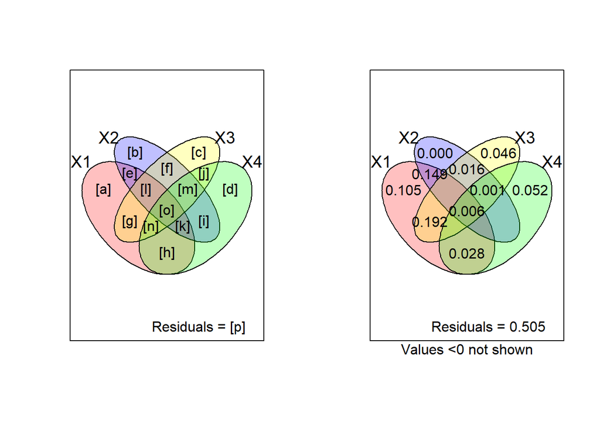

Variation partitioning of the undetrended tonga reef fish data into an environmental component (X1), a linear trend (X2), a positive scale dbMEM spatial component (X3) and negative spatial scale dbMEM spatial component (X4). The empty fractions in the plots have small negative R2_adj values. Together, 49.51% of the variation is explained, with a 10% increase when considering spatial variables.

### Beta Diversity

#### Replacement, richness and nestedness indices of the fish data

When comparing presence absence data to quantitative data we get:

|  | BD Total | Replacement | Richness Difference | Repl/TotalB | RichDif/TotalB |
| --- | --- | --- | --- | --- | --- |
| quantitative | 0.4169903 | 0.2717076 | 0.1452827 | 0.6515920 | 0.3484080 |
| presence/ absence | 0.34162115 | 0.26216129 | 0.07945986 | 0.76740358 | 0.23259642 |

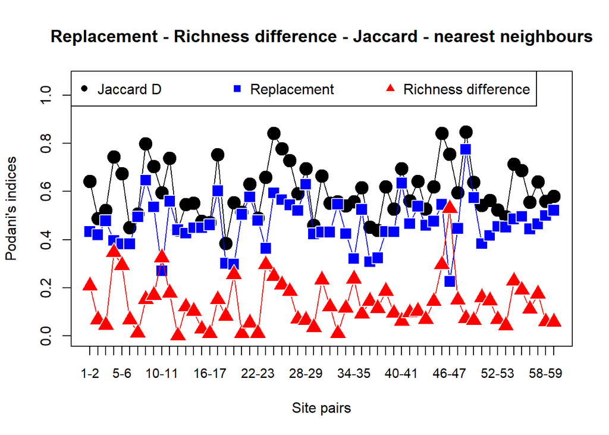

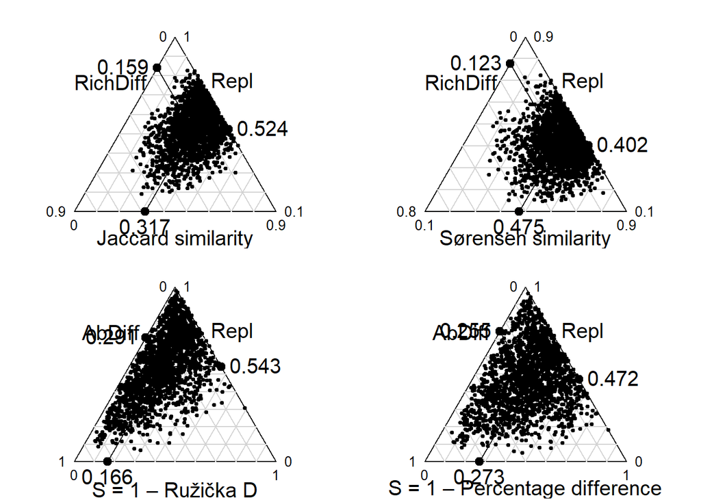

Triangle plots of all pairs of sites in the Tonga data set, based on the Podani indices of richness or abundance difference, replacement, and corresponding similarities. In each plot, the mean values of the indices, as well as the position of a “mean pair of sites”, are represented by larger black dots. Species replacement is also called turnover when analysed along spatial or environmental gradients. The results of the plots may suggest that the simultaneous gain and loss of species due to environmental filtering/competition is occuring (Legendre, 2014).

```r
# Display values of the mean points in the triangular plots
colMeans(fish.pod.J.3[, c(3, 1, 2)])
##   RichDiff Similarity       Repl
##  0.1589197  0.3167577  0.5243226
colMeans(fish.pod.S.3[, c(3, 1, 2)])
##   RichDiff Similarity       Repl
##  0.1227849  0.4752054  0.4020096
colMeans(fish.pod.qJ.3[, c(3, 1, 2)])
##     AbDiff Similarity       Repl
##  0.2905655  0.1660194  0.5434151
colMeans(fish.pod.qS.3[, c(3, 1, 2)])
##     AbDiff Similarity       Repl
##  0.2550097  0.2725305  0.4724599
```

Although both ANOVAs are significant, both the replacement (R^2_adj 0.0144) and the richness difference (R^2_adj 0.07098) show very weak relationships of the replacement/richness matrix with the environmental variables. This may be do to the very asymmetric community data or lack of appropriate environmental variables. Alternatively, the results may be explained by strong relationships to spatial and temporal variables which were not considered.

Species with SCBD larger than mean SCBD: - *Scarus flavipectoralis* 0.6365 - *Chromis chrysura* 0.0689 - *Chromis viridis* 0.05789 - *Pomacentrus callainus* 0.1149 - *Chrysiptera taupou* 0.1039 - *Chromis chrysura* 0.7198 –> Pomacentrus callainus, Chrysiptera taupou, Chromis chrysura, Amblyglyphidodon melanopterus, and Chromis chrysura explained most of the variation in the PCA biplots.

Sites with significant holm-correlated LCBD values: EFH1 (Euiki FHR), HkM2 (Hakau Manu 2), LgE2 (Lagoon Entrance 2)

Large LCBD values indicate sites that have strongly different species compositions compared with a mean site. The three significant sites may have unusual species combinations and high conservation value or degraded and species-poor sites that are good candidates for ecological restoration (Legendre and Gauthier, 2014).

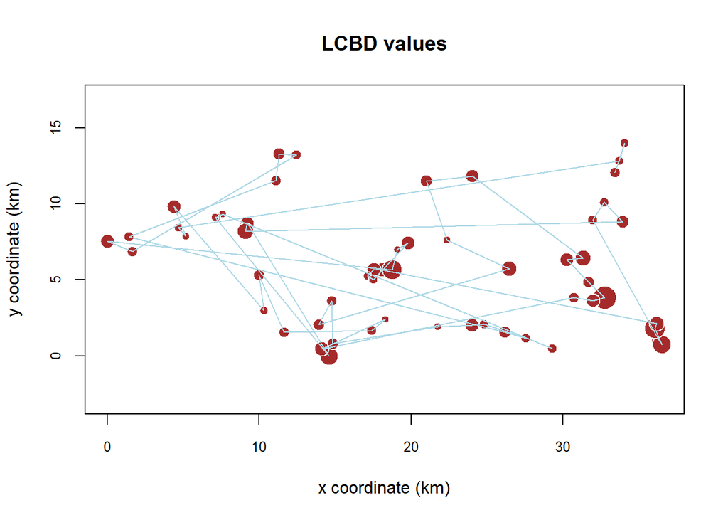

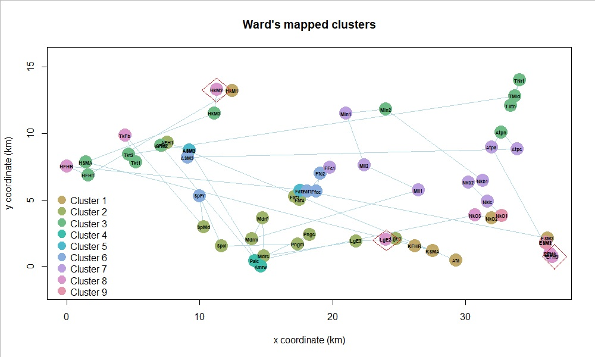